# Reproducible Research Course Project (Week 2)

Jeremias Lalis

May 11, 2016

Setting up the defaults:

```r
knitr::opts_chunk$set(echo = TRUE, results = "asis")
```

Code for downloading and reading in the dataset:

```r
if(!file.exists("getdata-projectfiles-UCI HAR Dataset.zip")) {
        temp <- tempfile()
        download.file("http://d396qusza40orc.cloudfront.net/repdata%2Fdata%2Factivity.zip",temp)
        unzip(temp)
        unlink(temp)
}
rawData <- read.csv("activity.csv", stringsAsFactors = FALSE)
dim(rawData)
```

[1] 17568 3

Code for preprocessing the data (Removing NAs):

```r
noNAData <- rawData[complete.cases(rawData), ]
dim(noNAData)
```

[1] 15264 3

### Q1: What is mean total number of steps taken per day?

#### Ans:

Histogram of the total number of steps taken each day.

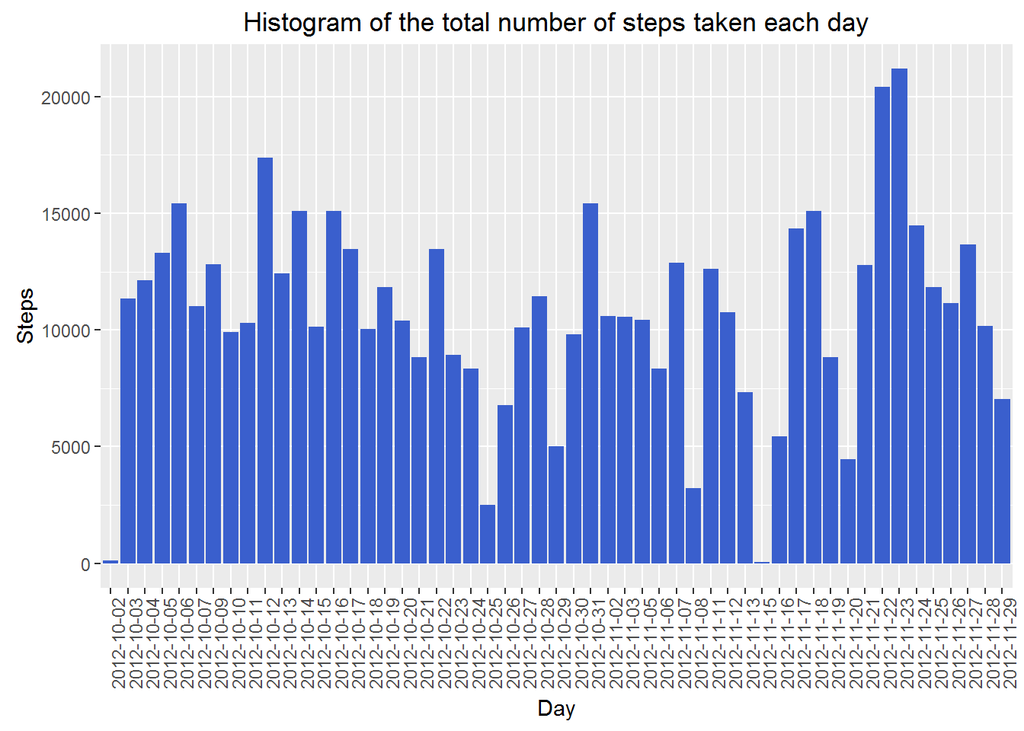

```r
library(ggplot2)
ggplot(noNAData, aes(as.factor(date),steps))+geom_bar(fill="royalblue3", stat="identity")+xlab("Day") + ylab("Steps")+ggtitle("Histogram of the total number of steps taken each day")+ theme(axis.text.x = element_text(angle = 90, hjust = 1))
```

```r
meanFreq <- as.integer(mean(aggregate(steps~date,noNAData, FUN=sum)$steps))
```

Mean number of steps taken each day is 10766.

```r
medianFreq <- median(aggregate(steps~date,noNAData, FUN=sum)$steps)
```

Median number of steps taken each day is 10765.

### Q2: What is the average daily activity pattern?

#### Ans:

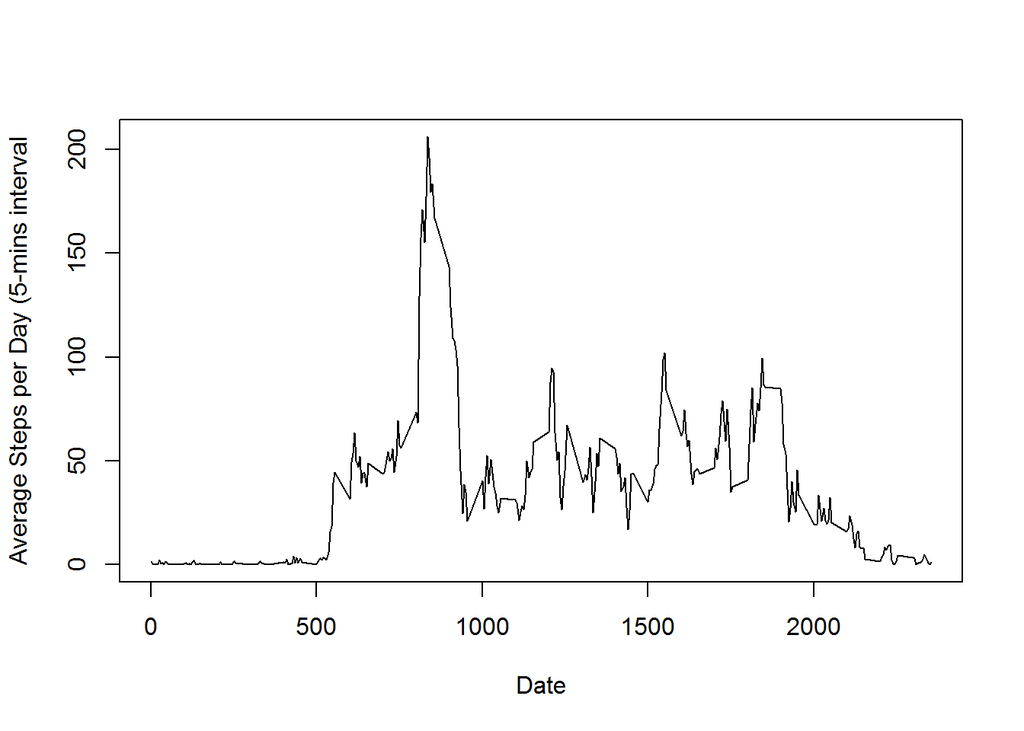

```r
q2 <- noNAData
q2 <- aggregate(steps~interval, q2, FUN=mean)
plot(q2$steps ~ q2$interval, type="l", xlab="Date", ylab="Average Steps per Day (5-mins interval")
```

Code to look for the maximum number of steps:

```r
maxSteps <- q2[q2$steps==max(q2$steps), ]
q2 <- NULL
```

The 5-minute interval 835, on average across all the days in the dataset, contains the maximum number of steps (206.1698113).

### Q3: Imputing missing values

#### Ans:

Code to calculate the total number of missing values in the dataset.

```r
numNA <- nrow(rawData) - nrow(noNAData)
```

The total number of rows with NAs in the dataset is 2304.

The simple strategy that I used in imputing the data is that I used the average steps taken for that specific interval in all of the data set and assign it to the missing value(s). The code for this strategy is the following:

```r
imputedData <- rawData
#The mean for that 5-minute interval
meanForNA <- aggregate(steps~interval,imputedData, FUN=mean)
for(i in 1:nrow(imputedData)){
  if(is.na(imputedData[i,c("steps")])){
    imputedData[i,c("steps")] <- meanForNA[meanForNA$interval==imputedData[i,c("interval")], c("steps")]
  }
}
```

Code to Show Histogram of the total number of steps taken each day after missing values are imputed.

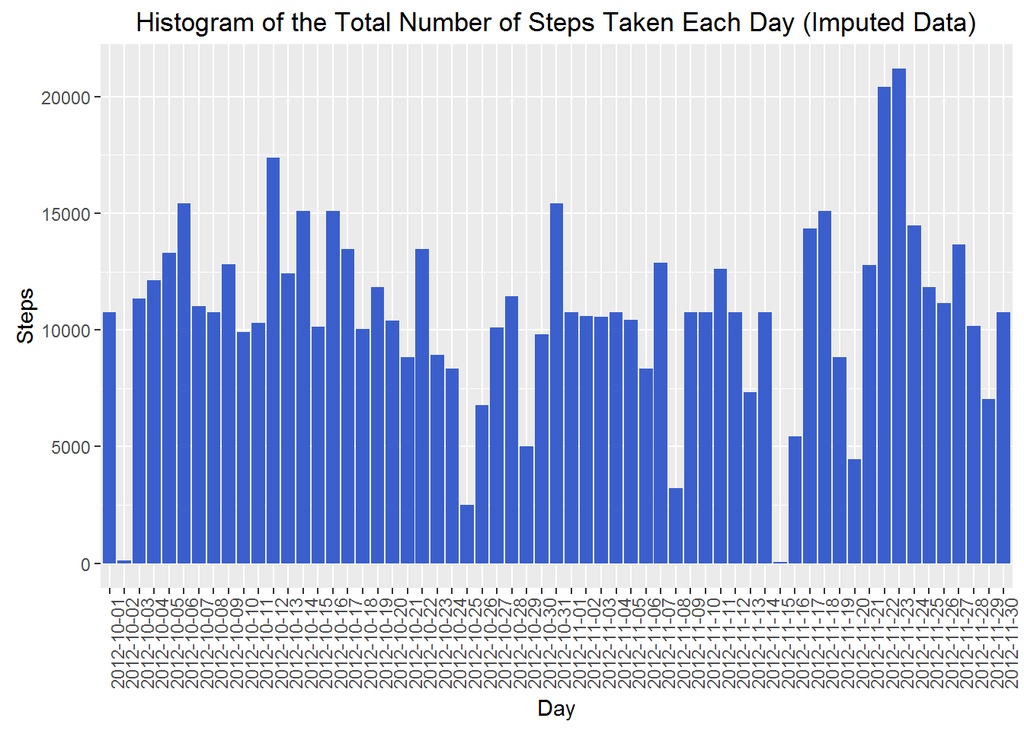

```r
ggplot(imputedData,aes(as.factor(date),steps))+geom_bar(fill="royalblue3", stat="identity")+xlab("Day") + ylab("Steps")+ggtitle("Histogram of the Total Number of Steps Taken Each Day (Imputed Data)")+ theme(axis.text.x = element_text(angle = 90, hjust = 1))
```

```r
newmeanFreq <- as.integer(mean(aggregate(steps~date,imputedData, FUN=sum)$steps))
newmedianFreq <- as.integer(median(aggregate(steps~date,imputedData, FUN=sum)$steps))
```

The new mean of the imputed data is 10766 steps compared to the old mean of 10766 steps. That creates a difference of 0 steps on average per day.

The new median of the imputed data is 10766 steps compared to the old median of 10765 steps. That creates a difference of 1 steps for the median.

This shows that the overall shape of the distribution has not changed after applying the method in imputing the data.

### Q4: Are there differences in activity patterns between weekdays and weekends?

#### Ans:

```r
weekDayEnd <- data.frame("dayType"=character(0))
weekDayEnd <- NULL

#Check wether the day is a weekday or weekend (Saturday)
weekInd <- function(day){
  if (weekdays(day)=="Saturday") {
    out <- "Weekend"
  } else {
    out <- "Weekday"
  }
  out
}

for (i in 1:nrow(imputedData)){
  date <- imputedData[i,c("date")]
  newObs <- data.frame("dayType"= weekInd(as.Date(date)))
  weekDayEnd <- rbind(weekDayEnd, newObs)
}
#------------------------------------------------------------

#Add the day type column in the data set
imputedData <- cbind(imputedData, weekDayEnd)
```

Panel plot comparing the average number of steps taken per 5-minute interval across weekdays and weekends.

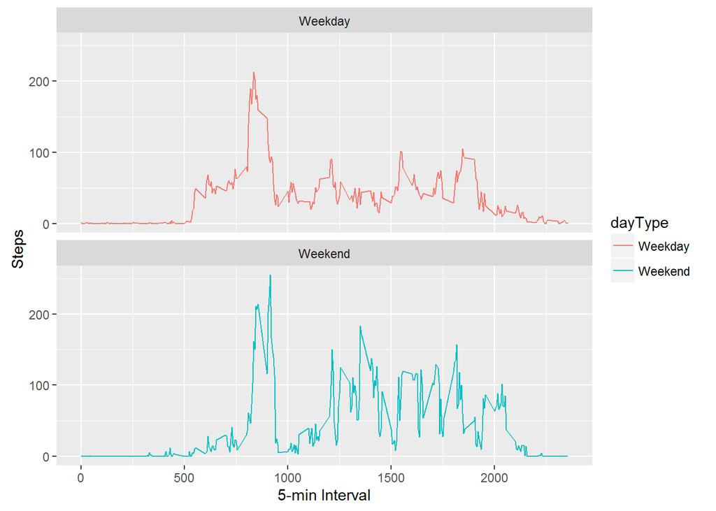

```r
averageWeekDayEnd<-aggregate(steps~interval + dayType, imputedData, FUN=mean)
ggplot(averageWeekDayEnd,aes(interval,steps, color=dayType))+geom_line()+facet_wrap(~dayType, ncol=1)+xlab("5-min Interval")+ylab("Steps")+guides(fill=FALSE)
```